# CourseProject

First of all, I load the required packages and read the data file and save it to a data.frame “data”. When I read the data file I used the na.strings=c(“NA”,“”) option.

```r
library(ISLR)
library(caret)
data=read.csv("pml-training.csv",na.strings=c("NA",""))
dim(data)
```

```
## [1] 19622   160
```

The data.frame consist of 19622 observations of 160 variables. To reduce number of predictors, I removed the columns that contains NA value.

```r
data1 <- data[, which(as.numeric(colSums(is.na(data)))==0)]
dim(data1)
```

```
## [1] 19622    60
```

And then I reduced the 160 variables to 60 variables. And then I selected only the numeric variables. And then I removed correlated predictors with r value more than 0.8 and then more than 0.5.

```r
data2=data1[,7:60]
dim(data2)
```

```
## [1] 19622    54
```

```r
M=abs(cor(data2[,-54]))
head(which(M>0.8,arr.ind=T))
```

```
##                  row col
## num_window         1   1
## roll_belt          2   2
## yaw_belt           4   2
## total_accel_belt   5   2
## accel_belt_y      10   2
## accel_belt_z      11   2
```

```r
data3=data2[,-c(4,5,10,11,9,12,19,25,26,29,30,32,47)]
M=abs(cor(data3[,-41]))
head(which(M>0.5,arr.ind=T))
```

```
##                  row col
## num_window         1   1
## roll_belt          2   2
## gyros_arm_z       14   2
## accel_arm_y       16   2
## pitch_belt         3   3
## accel_dumbbell_z  25   3
```

```r
data4=data3[,-c(2,3,4,6,7,10,12,14,15,16,17,19,20,21,22,25,35,36,40)]
M=abs(cor(data4[,-22]))
tail(which(M>0.5,arr.ind=T))
```

```
##                   row col
## gyros_forearm_x    17  17
## gyros_forearm_y    18  18
## magnet_dumbbell_z  12  19
## accel_forearm_z    19  19
## magnet_forearm_x   20  20
## magnet_forearm_y   21  21
```

```r
data5=data4[,-c(10,12)]
```

For further reducing variables, I performed exploratory analysis using bivariate plots, and removed 7 more variables. For example,

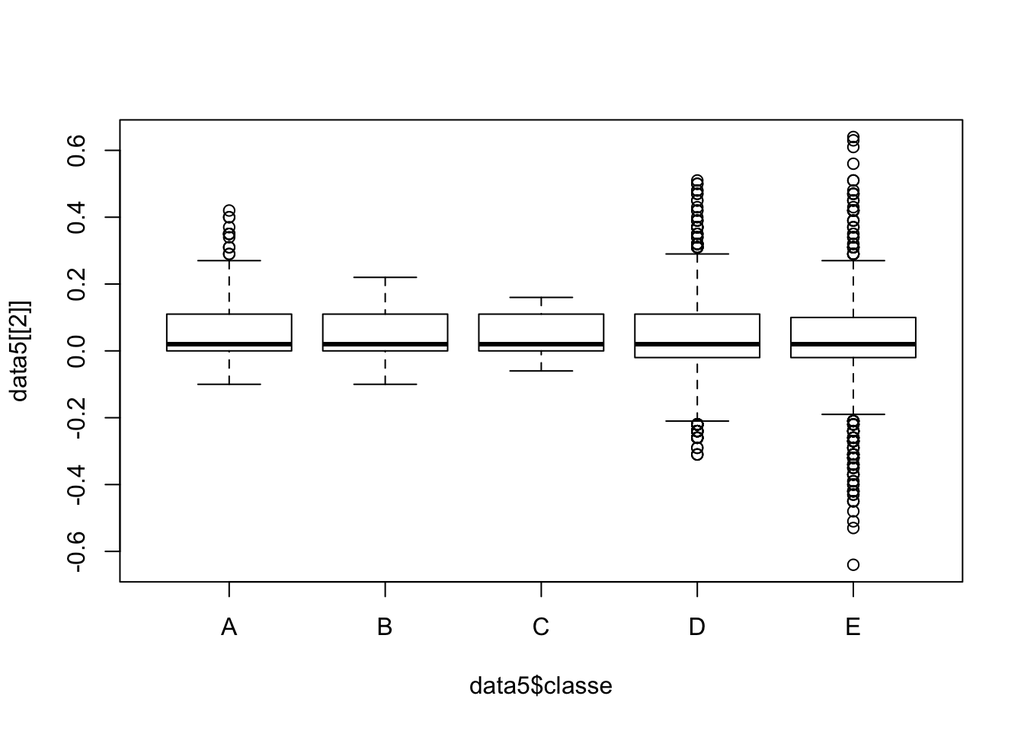

```r
plot(data5[[2]]~data5$classe,data=data5)
```

```r
data6=data5[,-c(2,5,10,14,15,16,17)]
```

and I removed 7 more variables. And than I made another exploratory graphs and selected 7 variables as predictors

[figure not shown]

[figure not shown]

```r
par(mfrow=c(1,2))
for(i in 1:12) {
plot(data6[[3]]~data6$classe,main=as.character(i))
plot(data6[[3]],col=data6$classe,main=as.character(i))
}
par(mfrow=c(1,1))
}
```

I chose 2nd variable as possible predictor and I removed the 8th variable. Final data file consist of 7 variables as predictors.

```r
data7=data6[,c(1,2,4,5,7,9,11,13)]
```

And then I split the data file into training data and testing data

```r
InTrain<-createDataPartition(y=data7$classe,p=0.7,list=FALSE)
training<-data7[InTrain,]
testing<-data7[-InTrain,]
dim(training);dim(testing)
```

```
## [1] 13737     8
```

```
## [1] 5885    8
```

And I used the random forest method as a machine learning model with 25 repetitions(bootstrapped).

```r
modFit<-train(classe~.,data=training,method="rf")
modFit
```

```
## Random Forest
##
## 13737 samples
##     7 predictors
##     5 classes: 'A', 'B', 'C', 'D', 'E'
##
## No pre-processing
## Resampling: Bootstrapped (25 reps)
##
## Summary of sample sizes: 13737, 13737, 13737, 13737, 13737, 13737, ...
##
## Resampling results across tuning parameters:
##
##   mtry  Accuracy  Kappa  Accuracy SD  Kappa SD
##   2     1         1      0.001        0.002
##   4     1         1      0.001        0.001
##   7     1         1      0.002        0.003
##
## Accuracy was used to select the optimal model using  the largest value.
## The final value used for the model was mtry = 4.
```

The final model selected showed 100% accuracy. I tested my final model to predict classe with testing data.

```r
pred<-predict(modFit,testing)
table(pred,testing$classe)
```

```
##
## pred    A    B    C    D    E
##    A 1673    0    0    0    0
##    B    1 1139    0    0    0
##    C    0    0 1026    1    0
##    D    0    0    0  963    0
##    E    0    0    0    0 1082
```